# Managing and publishing data

# Reading

- Hudon (2018)
- Wilkinson et al. (2016)

# The first rule of data management

*Do not edit your data.*

# Documentation

- Many social science fields have a tradition of writing codebooks for their data
  - [Stanford Open Policing codebook](https://github.com/stanford-policylab/opp/blob/master/data_readme.md)
  - [“Codebook-like summary” of the `covdata` package, automatically generated using `skimr`](https://kjhealy.github.io/covdata/articles/codebook.html)
  - Caitlin Hudon’s approach (Hudon 2018)
    - Table and field name, both verbatim
    - Field example value
    - Notes for both table and field

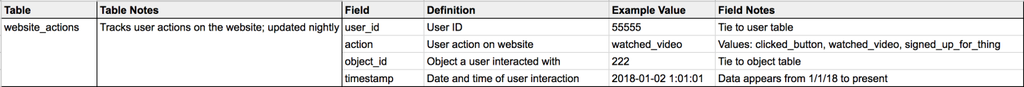

# Questions a codebook should answer

1. What does this field mean? How should I use it?
2. What is the data [journey]?
   - Where does this data come from?
   - How exactly is it collected?
   - How often is it updated?
   - Where does it go next?
3. What does the data in this field actually look like?
4. Are there any caveats to keep in mind when using this data?
5. Where can I go for more information?

(Hudon 2018)

# Major codebook elements

(https://afit-r.github.io/codebook)

1. Original source of the data
2. Sampling information
   - Where and how the data were generated
3. Variable-level metadata and summaries
4. Structure of the data

# Data management plans

- Much like a research plan, data management plans provide an overview of the steps you’ll take to gather, publish, and maintain your data
  - Since 2011, NSF has required a 2-page data management plan for most types of proposals
- Examples and resources
  - [UCM Library](https://library.ucmerced.edu/research/researchers/research-data-management/data-management-plans)
  - [UCSD NSF examples](https://library.ucsd.edu/lpw-staging/research-and-collections/data-curation/data-management/dmp-samples.html)
    - [SBE example 1](https://library.ucsd.edu/lpw-staging/research-and-collections/data-curation/data-management/dmpsample/DMP-Example-Ayelet-Gneezy.pdf)
    - [SBE example 2](https://library.ucsd.edu/lpw-staging/research-and-collections/data-curation/data-management/dmpsample/DMP-Example-Wixted.pdf)
  - [NSF policy summary](https://www.nsf.gov/bfa/dias/policy/dmp.jsp)
    - [SBE-specific guidance](https://www.nsf.gov/sbe/DMP/SBE_DataMgmtPlanPolicy_RevisedApril2018.pdf)

# Data management plan: Common elements

- Who is responsible for data management
- Who else will have access to which data
- How data will be collected
- Data formatting standards
- Whether and how data will be archived and made available for reuse

# FAIR principles for published data

- *Findable*
  - F1. (meta)data are assigned a globally unique and persistent identifier
  - F2. data are described with rich metadata (defined by R1 below)
  - F3. metadata clearly and explicitly include the identifier of the data it describes
  - F4. (meta)data are registered or indexed in a searchable resource
- *Accessible*
  - A1. (meta)data are retrievable by their identifier using a standardized communications protocol
    - A1.1 the protocol is open, free, and universally implementable
    - A1.2 the protocol allows for an authentication and authorization procedure, where necessary
  - A2. metadata are accessible, even when the data are no longer available
- *Interoperable*
  - I1. (meta)data use a formal, accessible, shared, and broadly applicable language for knowledge representation.
  - I2. (meta)data use vocabularies that follow FAIR principles
  - I3. (meta)data include qualified references to other (meta)data
- *Reusable*
  - R1. meta(data) are richly described with a plurality of accurate and relevant attributes
    - R1.1. (meta)data are released with a clear and accessible data usage license
    - R1.2. (meta)data are associated with detailed provenance
    - R1.3. (meta)data meet domain-relevant community standards

# DOIs for data

- [Instructions for OSF](https://help.osf.io/hc/en-us/articles/360019931013-Create-DOIs)
- [Notes for Zenodo](https://help.zenodo.org/#versioning)
  - [Zenodo also plays nicely with GitHub for minting DOIs for code](https://guides.github.com/activities/citable-code/)
- [Citation models at Harvard Dataverse](https://dataverse.org/best-practices/data-citation)

# References

Hudon, Caitlin. 2018. “Field Notes: Building Data Dictionaries.” Haystacks. October 30, 2018. https://caitlinhudon.com/2018/10/30/data-dictionaries/.

Wilkinson, Mark D., Michel Dumontier, IJsbrand Jan Aalbersberg, Gabrielle Appleton, Myles Axton, Arie Baak, Niklas Blomberg, et al. 2016. “The FAIR Guiding Principles for Scientific Data Management and Stewardship.” *Scientific Data* 3 (1, 1): 1–9. https://doi.org/10.1038/sdata.2016.18.